# Lab8

Adrián González, Jose Ordoñez, Daniela Ramírez

2026-04-24

Link de Github: https://github.com/Ikeel04/Lab6-MD.git

## Librerías y carga de datos

```r
library(dplyr)
```

```r
library(ggplot2)
library(caret)
library(e1071)
library(tidyr)
library(scales)
library(kableExtra)
library(reshape2)
library(gridExtra)
library(nnet)
```

```r
load("listings.RData")
```

## Inciso 1

### Conjuntos de entrenamiento y prueba

Para mantener comparabilidad con todos los laboratorios anteriores, se utilizan los mismos conjuntos de entrenamiento y prueba generados. Las variables predictoras y la variable respuesta son las mismas que en entregas previas.

```r
listings$price <- as.numeric(gsub("[$,]", "", listings$price))
listings <- listings %>% filter(!is.na(price), price > 0)

p33 <- quantile(listings$price, 0.33, na.rm = TRUE)
p66 <- quantile(listings$price, 0.66, na.rm = TRUE)

listings$price_category <- cut(
  listings$price,
  breaks = c(-Inf, p33, p66, Inf),
  labels = c("Economica", "Intermedia", "Cara")
)

vars_num <- c("accommodates", "bathrooms", "bedrooms", "beds",
              "minimum_nights", "number_of_reviews", "review_scores_rating",
              "reviews_per_month", "calculated_host_listings_count",
              "availability_365")

vars_disp <- intersect(vars_num, names(listings))
datos <- listings[, c("price", vars_disp, "price_category")]

# Imputación de NAs con mediana
for (col in c("price", vars_disp)) {
  datos[[col]][is.na(datos[[col]])] <- median(datos[[col]], na.rm = TRUE)
}

set.seed(123)
idx <- createDataPartition(datos$price_category, p = 0.70, list = FALSE)

train_data <- datos[idx, ]
test_data  <- datos[-idx, ]

cat("Entrenamiento:", nrow(train_data), "observaciones\n")
```

```
## Entrenamiento: 53373 observaciones
```

```r
cat("Prueba       :", nrow(test_data),  "observaciones\n")
```

```
## Prueba       : 22873 observaciones
```

```r
cat("Distribución de clases en entrenamiento:\n")
```

```
## Distribución de clases en entrenamiento:
```

```r
print(prop.table(table(train_data$price_category)) * 100)
```

```
##
##  Economica Intermedia       Cara
##   33.03168   33.00358   33.96474
```

El dataset quedó dividido manteniendo la proporción 70/30. La distribución de clases es prácticamente uniforme.

## Inciso 2

### Exploración y transformaciones para SVM

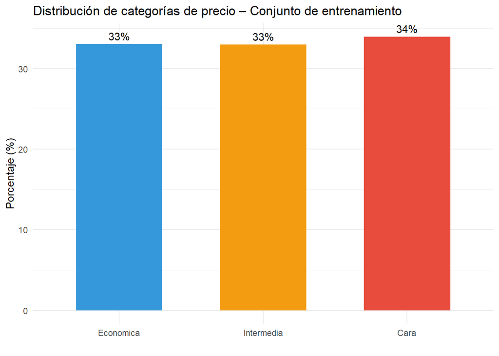

```r
dist_clases <- as.data.frame(prop.table(table(train_data$price_category)) * 100)
names(dist_clases) <- c("Categoria", "Porcentaje")

ggplot(dist_clases, aes(x = Categoria, y = Porcentaje, fill = Categoria)) +
  geom_bar(stat = "identity", width = 0.6) +
  geom_text(aes(label = paste0(round(Porcentaje, 1), "%")), vjust = -0.5) +
  scale_fill_manual(values = c("Economica" = "#3498db",
                               "Intermedia" = "#f39c12",
                               "Cara"       = "#e74c3c")) +
  labs(title = "Distribución de categorías de precio – Conjunto de entrenamiento",
       x = "", y = "Porcentaje (%)") +
  theme_minimal() +
  theme(legend.position = "none")
```

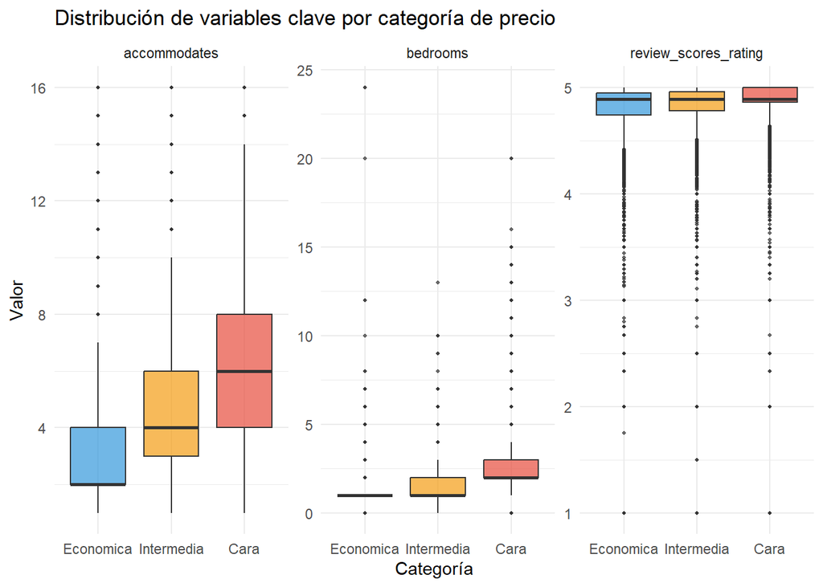

```r
# Relación entre variables clave y categoría de precio
train_long <- train_data %>%
  select(price_category, accommodates, bedrooms, review_scores_rating) %>%
  pivot_longer(-price_category, names_to = "Variable", values_to = "Valor")

ggplot(train_long, aes(x = price_category, y = Valor, fill = price_category)) +
  geom_boxplot(alpha = 0.7, outlier.size = 0.8) +
  facet_wrap(~ Variable, scales = "free_y") +
  scale_fill_manual(values = c("Economica" = "#3498db",
                               "Intermedia" = "#f39c12",
                               "Cara"       = "#e74c3c")) +
  labs(title = "Distribución de variables clave por categoría de precio",
       x = "Categoría", y = "Valor") +
  theme_minimal() +
  theme(legend.position = "none")
```

Los boxplots confirman que las variables accommodates y bedrooms tienen una gran influencia entre categorías, las propiedades caras tienen mediana de capacidad y habitaciones notablemente mayor que las económicas. En cambio, review_scores_rating muestra distribuciones casi idénticas entre las tres categorías, lo que indica que la calificación de los huéspedes no es un predictor relevante del precio en este dataset. Esto es relevante para SmartStay: una propiedad bien calificada no necesariamente es cara, por lo que el precio depende más de características físicas que de la percepción del cliente.

```r
predictores <- vars_disp

x_train <- scale(train_data[, predictores])
x_test  <- scale(test_data[, predictores],
                 center = attr(x_train, "scaled:center"),
                 scale  = attr(x_train, "scaled:scale"))

# Reconstruimos los data frames escalados con la variable respuesta
train_svm <- as.data.frame(x_train)
train_svm$price_category <- train_data$price_category

test_svm  <- as.data.frame(x_test)
test_svm$price_category  <- test_data$price_category

cat("Verificación de escala (media y SD de 'accommodates' en train):\n")
```

```
## Verificación de escala (media y SD de 'accommodates' en train):
```

```r
cat("  Media:", round(mean(train_svm$accommodates), 4), "\n")
```

```
##   Media: 0
```

```r
cat("  SD   :", round(sd(train_svm$accommodates),   4), "\n")
```

```
##   SD   : 1
```

## Inciso 3

### Variable respuesta: categoría de precio

La variable respuesta es price_category, construida en entregas anteriores a partir de los percentiles 33 y 66 del precio.

```r
tabla_clases <- data.frame(
  Categoria  = c("Económica", "Intermedia", "Cara"),
  Umbral     = c(paste0("≤ $", round(p33, 2)),
                 paste0("$", round(p33, 2), " – $", round(p66, 2)),
                 paste0("> $", round(p66, 2))),
  N_train    = as.integer(table(train_data$price_category)),
  Pct_train  = paste0(round(prop.table(table(train_data$price_category)) * 100, 1), "%")
)

knitr::kable(tabla_clases,
             col.names = c("Categoría", "Rango de precio", "N (train)", "% (train)"),
             caption   = "Definición y distribución de la variable respuesta")
```

Definición y distribución de la variable respuesta

| Categoría | Rango de precio | N (train) | % (train) |
| --- | --- | --- | --- |
| Económica | ≤ $141 | 17630 | 33% |
| Intermedia | $141 – $264 | 17615 | 33% |
| Cara | > $264 | 18128 | 34% |

Las propiedades económicas tienen un precio de hasta 141 USD por noche, las intermedias entre 141 y 264, y las caras superan los 264. Con 17,630, 17,615 y 18,128 observaciones respectivamente en entrenamiento, las clases se miran balanceadas, lo que es una condición favorable para SVM ya que el hiperplano separador no se verá forzado hacia ninguna clase dominante.

## Inciso 4

### Generación de modelos SVM

```r
# modelo 1
set.seed(123)
svm_lineal_1 <- svm(
  price_category ~ .,
  data   = train_svm,
  kernel = "linear",
  cost   = 0.1,
  scale  = FALSE
)
summary(svm_lineal_1)
```

```
##
## Call:
## svm(formula = price_category ~ ., data = train_svm, kernel = "linear",
##     cost = 0.1, scale = FALSE)
##
##
## Parameters:
##    SVM-Type:  C-classification
##  SVM-Kernel:  linear
##        cost:  0.1
##
## Number of Support Vectors:  42029
##
##  ( 17428 12435 12166 )
##
##
## Number of Classes:  3
##
## Levels:
##  Economica Intermedia Cara
```

```r
# modelo 2
set.seed(123)
svm_lineal_2 <- svm(
  price_category ~ .,
  data   = train_svm,
  kernel = "linear",
  cost   = 10,
  scale  = FALSE
)
summary(svm_lineal_2)
```

```
##
## Call:
## svm(formula = price_category ~ ., data = train_svm, kernel = "linear",
##     cost = 10, scale = FALSE)
##
##
## Parameters:
##    SVM-Type:  C-classification
##  SVM-Kernel:  linear
##        cost:  10
##
## Number of Support Vectors:  42009
##
##  ( 17426 12423 12160 )
##
##
## Number of Classes:  3
##
## Levels:
##  Economica Intermedia Cara
```

```r
# modelo 3
set.seed(123)
svm_rbf_1 <- svm(
  price_category ~ .,
  data   = train_svm,
  kernel = "radial",
  cost   = 1,
  gamma  = 0.01,
  scale  = FALSE
)
summary(svm_rbf_1)
```

```
##
## Call:
## svm(formula = price_category ~ ., data = train_svm, kernel = "radial",
##     cost = 1, gamma = 0.01, scale = FALSE)
##
##
## Parameters:
##    SVM-Type:  C-classification
##  SVM-Kernel:  radial
##        cost:  1
##
## Number of Support Vectors:  40938
##
##  ( 17205 11908 11825 )
##
##
## Number of Classes:  3
##
## Levels:
##  Economica Intermedia Cara
```

```r
# modelo 4
set.seed(123)
svm_poly_1 <- svm(
  price_category ~ .,
  data   = train_svm,
  kernel = "polynomial",
  cost   = 5,
  gamma  = 0.01,
  degree = 3,
  scale  = FALSE
)
summary(svm_poly_1)
```

```
##
## Call:
## svm(formula = price_category ~ ., data = train_svm, kernel = "polynomial",
##     cost = 5, gamma = 0.01, degree = 3, scale = FALSE)
##
##
## Parameters:
##    SVM-Type:  C-classification
##  SVM-Kernel:  polynomial
##        cost:  5
##      degree:  3
##      coef.0:  0
##
## Number of Support Vectors:  47912
##
##  ( 17269 15934 14709 )
##
##
## Number of Classes:  3
##
## Levels:
##  Economica Intermedia Cara
```

Se entrenaron cuatro modelos SVM con diferentes kernels y parámetros para comparar su desempeño. Dos modelos utilizaron kernel lineal variando el costo (C=0.1 y C=10), uno utilizó kernel RBF (C=1, γ=0.01) y otro kernel polinomial (C=5, γ=0.01, d=3). Esto permite evaluar desde el modelo más simple hasta el más flexible.

## Inciso 5

### Predicción

```r
# Modelo 1 – Lineal, C = 0.1
pred_lineal_1 <- predict(svm_lineal_1, newdata = test_svm)
cm1 <- confusionMatrix(pred_lineal_1, test_svm$price_category)
cm1$overall
```

```
##       Accuracy          Kappa  AccuracyLower  AccuracyUpper   AccuracyNull
##   5.972107e-01   3.956115e-01   5.908207e-01   6.035759e-01   3.396581e-01
## AccuracyPValue  McnemarPValue
##   0.000000e+00  4.150702e-158
```

```r
# Modelo 2 – Lineal, C = 10
pred_lineal_2 <- predict(svm_lineal_2, newdata = test_svm)
cm2 <- confusionMatrix(pred_lineal_2, test_svm$price_category)
cm2$overall
```

```
##       Accuracy          Kappa  AccuracyLower  AccuracyUpper   AccuracyNull
##   5.972981e-01   3.957426e-01   5.909084e-01   6.036631e-01   3.396581e-01
## AccuracyPValue  McnemarPValue
##   0.000000e+00  5.217548e-155
```

```r
# Modelo 3 – RBF, C = 1, gamma = 0.01
pred_rbf_1 <- predict(svm_rbf_1, newdata = test_svm)
cm3 <- confusionMatrix(pred_rbf_1, test_svm$price_category)
cm3$overall
```

```
##       Accuracy          Kappa  AccuracyLower  AccuracyUpper   AccuracyNull
##   6.150046e-01   4.225086e-01   6.086624e-01   6.213175e-01   3.396581e-01
## AccuracyPValue  McnemarPValue
##   0.000000e+00   1.578026e-17
```

```r
# Modelo 4 – Polinomial, C = 5, gamma = 0.01, d = 3
pred_poly_1 <- predict(svm_poly_1, newdata = test_svm)
cm4 <- confusionMatrix(pred_poly_1, test_svm$price_category)
cm4$overall
```

```
##       Accuracy          Kappa  AccuracyLower  AccuracyUpper   AccuracyNull
##      0.5366589      0.3069889      0.5301705      0.5431381      0.3396581
## AccuracyPValue  McnemarPValue
##      0.0000000      0.0000000
```

Los cuatro modelos SVM presentan un desempeño moderado. El kernel RBF fue el mejor con 61.5% de accuracy y Kappa de 0.42, seguido de los dos modelos lineales que obtuvieron exactamente el mismo resultado (59.7%), lo que indica que variar el costo no tuvo efecto en este caso. El modelo polinomial fue el de menor desempeño con 53.7%, sugiriendo que el grado 3 generó una frontera demasiado compleja para este dataset. Los valores de Kappa entre 0.31 y 0.42 reflejan un acuerdo justo a moderado, esperado dado el traslape natural entre las categorías de precio.

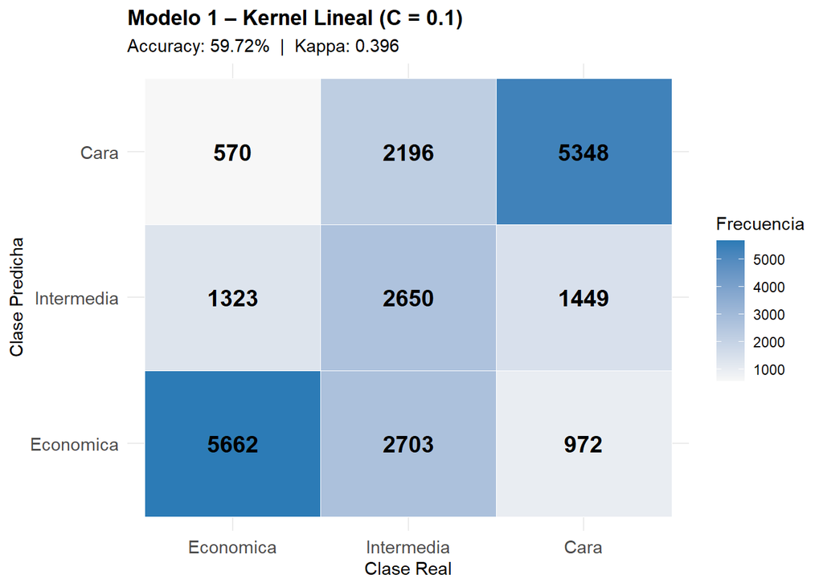

```r
# Función para graficar matriz de confusión
plot_cm <- function(cm, titulo) {
  cm_table <- as.data.frame(cm$table)

  ggplot(cm_table, aes(x = Reference, y = Prediction, fill = Freq)) +
    geom_tile(color = "white") +
    geom_text(aes(label = Freq), size = 5, fontface = "bold") +
    scale_fill_gradient(low = "#f7f7f7", high = "#2c7bb6") +
    labs(title = titulo,
         subtitle = paste0("Accuracy: ", round(cm$overall["Accuracy"] * 100, 2),
                           "%  |  Kappa: ", round(cm$overall["Kappa"], 3)),
         x = "Clase Real", y = "Clase Predicha", fill = "Frecuencia") +
    theme_minimal() +
    theme(plot.title = element_text(face = "bold", size = 13),
          axis.text = element_text(size = 11))
}

# Gráficas individuales
plot_cm(cm1, "Modelo 1 – Kernel Lineal (C = 0.1)")
```

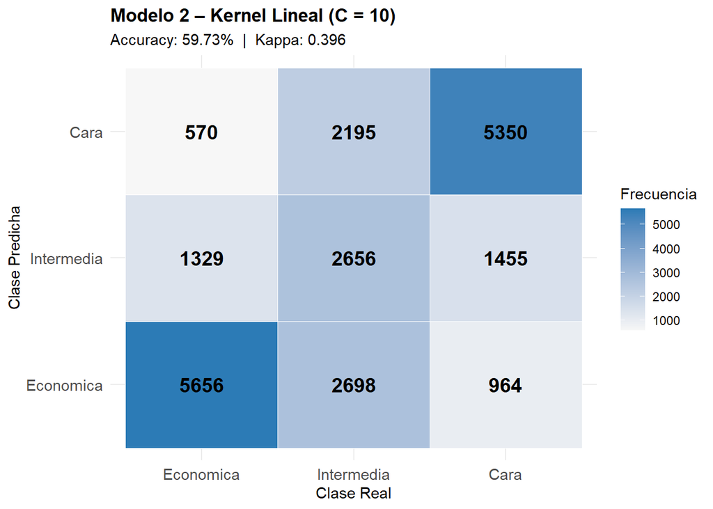

```r
plot_cm(cm2, "Modelo 2 – Kernel Lineal (C = 10)")
```

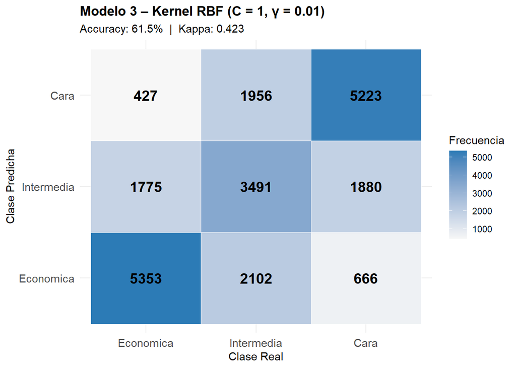

```r
plot_cm(cm3, "Modelo 3 – Kernel RBF (C = 1, γ = 0.01)")
```

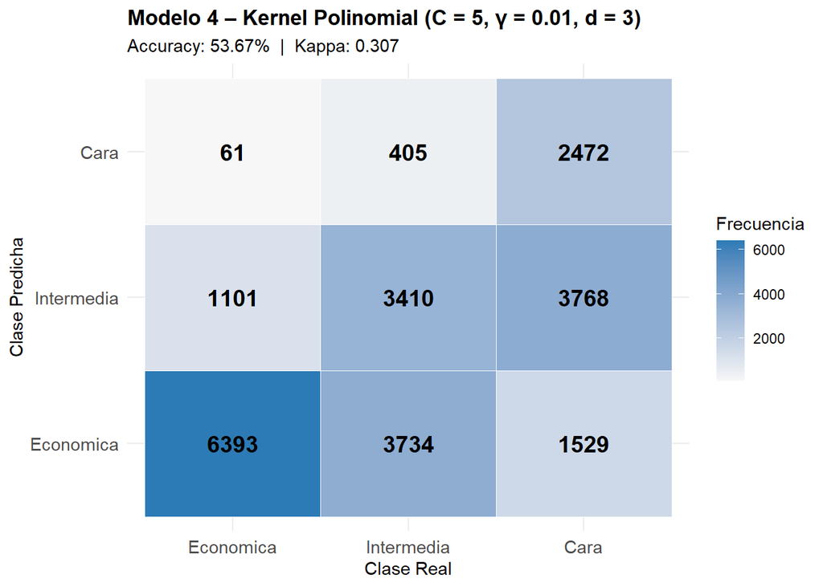

```r
plot_cm(cm4, "Modelo 4 – Kernel Polinomial (C = 5, γ = 0.01, d = 3)")
```

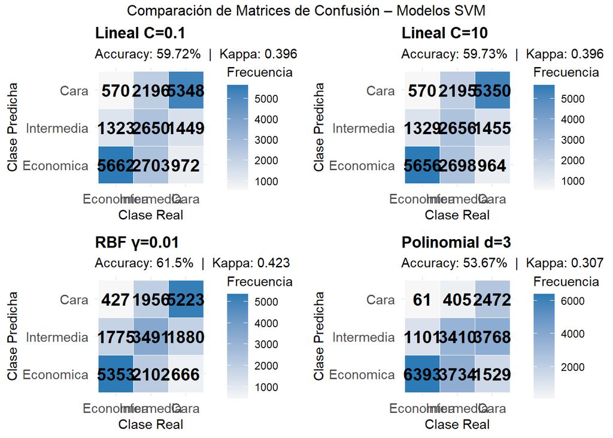

```r
# Panel comparativo de los 4 modelos
g1 <- plot_cm(cm1, "Lineal C=0.1")
g2 <- plot_cm(cm2, "Lineal C=10")
g3 <- plot_cm(cm3, "RBF γ=0.01")
g4 <- plot_cm(cm4, "Polinomial d=3")

grid.arrange(g1, g2, g3, g4, ncol = 2,
             top = "Comparación de Matrices de Confusión – Modelos SVM")
```

Los cuatro modelos fueron evaluados sobre 22,873 observaciones de prueba. El kernel RBF fue el mejor con 61.50% de accuracy y Kappa de 0.42, seguido de los dos modelos lineales con resultados casi idénticos (~59.7%), lo que indica que variar el costo entre 0.1 y 10 no tuvo efecto relevante. El modelo polinomial fue el peor con 53.67% y Kappa de 0.31.

```r
## Inciso 7
### Análisis de sobreajuste

# Predicciones sobre entrenamiento para comparar con prueba
pred_train_1 <- predict(svm_lineal_1, newdata = train_svm)
pred_train_2 <- predict(svm_lineal_2, newdata = train_svm)
pred_train_3 <- predict(svm_rbf_1,    newdata = train_svm)
pred_train_4 <- predict(svm_poly_1,   newdata = train_svm)

acc_train <- c(
  mean(pred_train_1 == train_svm$price_category),
  mean(pred_train_2 == train_svm$price_category),
  mean(pred_train_3 == train_svm$price_category),
  mean(pred_train_4 == train_svm$price_category)
)

acc_test <- c(0.5972, 0.5973, 0.6150, 0.5367)

tabla_ajuste <- data.frame(
  Modelo     = c("Lineal C=0.1", "Lineal C=10", "RBF C=1 γ=0.01", "Polinomial d=3"),
  Acc_Train  = round(acc_train, 4),
  Acc_Test   = acc_test,
  Diferencia = round(acc_train - acc_test, 4)
)

knitr::kable(tabla_ajuste,
             col.names = c("Modelo", "Accuracy Train", "Accuracy Test", "Diferencia"),
             caption = "Comparación de ajuste: entrenamiento vs prueba")
```

Comparación de ajuste: entrenamiento vs prueba

| Modelo | Accuracy Train | Accuracy Test | Diferencia |
| --- | --- | --- | --- |
| Lineal C=0.1 | 0.5969 | 0.5972 | -3e-04 |
| Lineal C=10 | 0.5970 | 0.5973 | -3e-04 |
| RBF C=1 γ=0.01 | 0.6150 | 0.6150 | 0e+00 |
| Polinomial d=3 | 0.5369 | 0.5367 | 2e-04 |

Las diferencias entre accuracy de entrenamiento y prueba son prácticamente nulas en los cuatro modelos, por lo que ninguno presenta sobreajuste. Sin embargo, el accuracy moderado en ambos conjuntos (~60%) indica un desajuste leve, los modelos no capturan completamente la complejidad del problema.

El modelo RBF es el más estable con diferencia de 0, siendo el mejor balance entre capacidad y generalización. El polinomial presenta el peor caso: alta complejidad pero bajo desempeño en ambos conjuntos (~53.7%), confirmando que el grado 3 no fue adecuado para este dataset. Para corregir esto estaría bien un tuneo de hiperparámetros con validación cruzada.

## Inciso 8

### Comparación entre modelos SVM: efectividad, tiempo y errores

```r
t1 <- system.time(predict(svm_lineal_1, newdata = test_svm))["elapsed"]
t2 <- system.time(predict(svm_lineal_2, newdata = test_svm))["elapsed"]
t3 <- system.time(predict(svm_rbf_1,    newdata = test_svm))["elapsed"]
t4 <- system.time(predict(svm_poly_1,   newdata = test_svm))["elapsed"]
```

```r
byclass_1 <- round(cm1$byClass[, c("Sensitivity", "Specificity", "F1")], 4)
byclass_3 <- round(cm3$byClass[, c("Sensitivity", "Specificity", "F1")], 4)

tabla_comp_svm <- data.frame(
  Modelo      = c("Lineal C=0.1", "Lineal C=10", "RBF C=1 γ=0.01", "Polinomial d=3"),
  Kernel      = c("linear", "linear", "radial", "polynomial"),
  Accuracy    = c(0.5972, 0.5973, 0.6150, 0.5367),
  Kappa       = c(0.3956, 0.3957, 0.4225, 0.3070),
  Tiempo_pred = c(round(t1, 3), round(t2, 3), round(t3, 3), round(t4, 3))
)

knitr::kable(tabla_comp_svm,
             col.names = c("Modelo", "Kernel", "Accuracy", "Kappa", "Tiempo pred. (seg)"),
             caption   = "Comparación de modelos SVM – efectividad y tiempo de predicción")
```

Comparación de modelos SVM – efectividad y tiempo de predicción

| Modelo | Kernel | Accuracy | Kappa | Tiempo pred. (seg) |
| --- | --- | --- | --- | --- |
| Lineal C=0.1 | linear | 0.5972 | 0.3956 | 20.19 |
| Lineal C=10 | linear | 0.5973 | 0.3957 | 19.52 |
| RBF C=1 γ=0.01 | radial | 0.6150 | 0.4225 | 87.75 |
| Polinomial d=3 | polynomial | 0.5367 | 0.3070 | 27.39 |

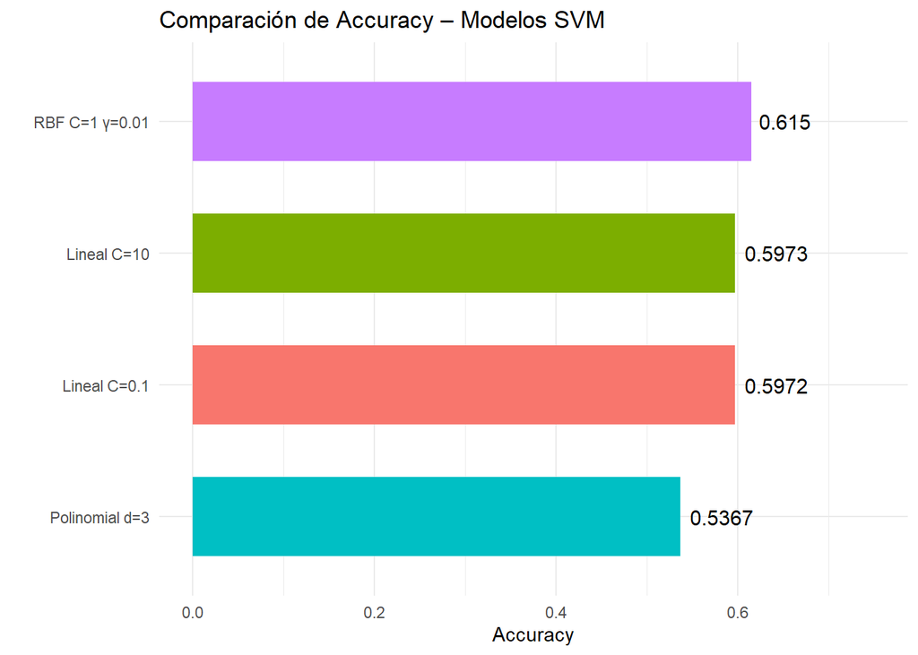

```r
ggplot(tabla_comp_svm, aes(x = reorder(Modelo, Accuracy), y = Accuracy, fill = Modelo)) +
  geom_bar(stat = "identity", width = 0.6) +
  geom_text(aes(label = round(Accuracy, 4)), hjust = -0.15, size = 4) +
  coord_flip() +
  ylim(0, 0.75) +
  labs(title = "Comparación de Accuracy – Modelos SVM",
       x = "", y = "Accuracy") +
  theme_minimal() +
  theme(legend.position = "none")
```

```r
errores_rbf  <- as.data.frame(cm3$byClass[, c("Sensitivity", "Specificity", "F1")])
errores_poly <- as.data.frame(cm4$byClass[, c("Sensitivity", "Specificity", "F1")])

errores_rbf$Modelo  <- "RBF (mejor)"
errores_rbf$Clase   <- rownames(errores_rbf)
errores_poly$Modelo <- "Polinomial (peor)"
errores_poly$Clase  <- rownames(errores_poly)

errores_combined <- rbind(errores_rbf, errores_poly)

knitr::kable(round(errores_rbf[, c("Sensitivity","Specificity","F1")], 4),
             caption = "Métricas por clase – Modelo RBF (mejor SVM)")
```

Métricas por clase – Modelo RBF (mejor SVM)

|  | Sensitivity | Specificity | F1 |
| --- | --- | --- | --- |
| Class: Economica | 0.7085 | 0.8193 | 0.6830 |
| Class: Intermedia | 0.4624 | 0.7615 | 0.4751 |
| Class: Cara | 0.6723 | 0.8422 | 0.6794 |

```r
knitr::kable(round(errores_poly[, c("Sensitivity","Specificity","F1")], 4),
             caption = "Métricas por clase – Modelo Polinomial (peor SVM)")
```

Métricas por clase – Modelo Polinomial (peor SVM)

|  | Sensitivity | Specificity | F1 |
| --- | --- | --- | --- |
| Class: Economica | 0.8462 | 0.6564 | 0.6656 |
| Class: Intermedia | 0.4517 | 0.6823 | 0.4309 |
| Class: Cara | 0.3182 | 0.9691 | 0.4618 |

## Inciso 9

### Comparación del mejor SVM con modelos de entregas anteriores

```r
set.seed(123)
tiempo_lr <- system.time({
  modelo_lr <- multinom(price_category ~ ., data = train_svm, trace = FALSE)
})

pred_lr <- predict(modelo_lr, newdata = test_svm)
cm_lr   <- confusionMatrix(pred_lr, test_svm$price_category)

cat("Regresión Logística Multinomial\n")
```

```
## Regresión Logística Multinomial
```

```r
cat("Accuracy:", round(cm_lr$overall["Accuracy"], 4), "\n")
```

```
## Accuracy: 0.6024
```

```r
cat("Kappa   :", round(cm_lr$overall["Kappa"],    4), "\n")
```

```
## Kappa   : 0.4035
```

```r
cat("Tiempo  :", round(tiempo_lr["elapsed"], 3), "seg\n")
```

```
## Tiempo  : 1.82 seg
```

```r
comparacion_final <- data.frame(
  Modelo      = c("Naive Bayes", "SVM RBF (Lab8)", "Regresión Logística",
                  "KNN (k=31)",  "Árbol de Decisión", "Random Forest"),
  Accuracy    = c(0.5886, 0.6150, round(cm_lr$overall["Accuracy"], 4),
                  0.6661, 0.6896, 0.8593),
  Kappa       = c(0.3549, 0.4225, round(cm_lr$overall["Kappa"], 4),
                  0.4414, NA,     0.7714),
  Tiempo_seg  = c(0.055,  NA,     round(tiempo_lr["elapsed"], 3),
                  NA,     0.517,  0.523)
)

knitr::kable(comparacion_final,
             col.names = c("Modelo", "Accuracy", "Kappa", "Tiempo (seg)"),
             caption   = "Comparación final – Modelos de clasificación (misma partición 70/30)")
```

Comparación final – Modelos de clasificación (misma partición 70/30)

| Modelo | Accuracy | Kappa | Tiempo (seg) |
| --- | --- | --- | --- |
| Naive Bayes | 0.5886 | 0.3549 | 0.055 |
| SVM RBF (Lab8) | 0.6150 | 0.4225 | NA |
| Regresión Logística | 0.6024 | 0.4035 | 1.820 |
| KNN (k=31) | 0.6661 | 0.4414 | NA |
| Árbol de Decisión | 0.6896 | NA | 0.517 |
| Random Forest | 0.8593 | 0.7714 | 0.523 |

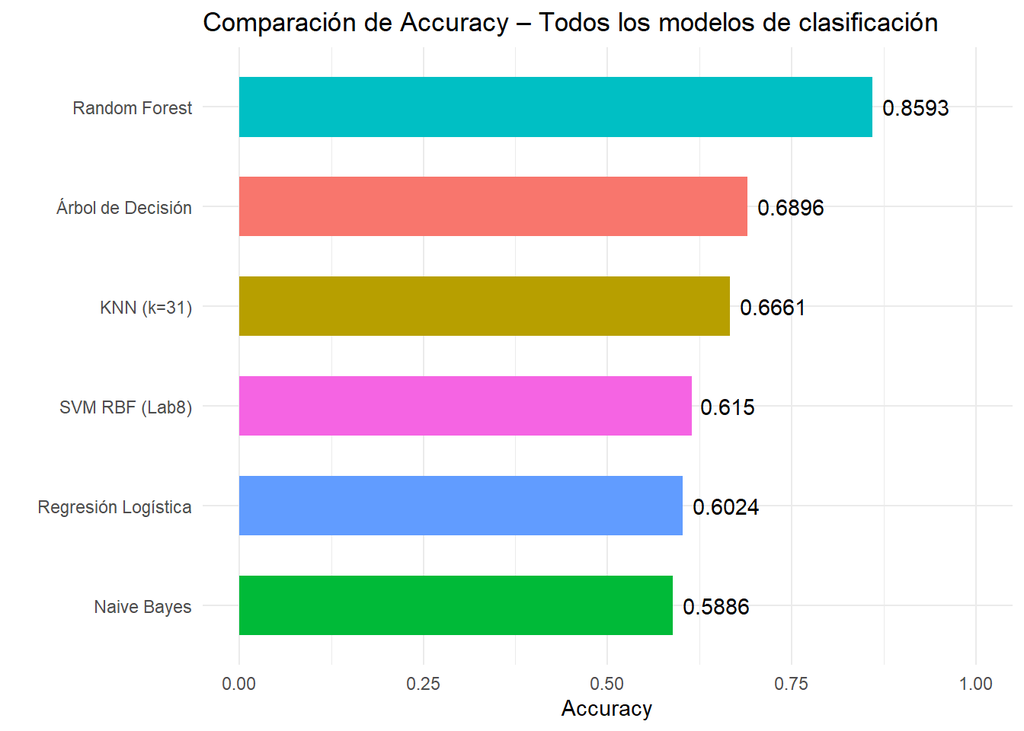

```r
ggplot(comparacion_final,
       aes(x = reorder(Modelo, Accuracy), y = Accuracy, fill = Modelo)) +
  geom_bar(stat = "identity", width = 0.6) +
  geom_text(aes(label = round(Accuracy, 4)), hjust = -0.15, size = 3.8) +
  coord_flip() +
  ylim(0, 1) +
  labs(title = "Comparación de Accuracy – Todos los modelos de clasificación",
       x = "", y = "Accuracy") +
  theme_minimal() +
  theme(legend.position = "none")
```

## Inciso 10

### Análisis de sobreajuste

```r
acc_train_lr  <- mean(predict(modelo_lr,  newdata = train_svm) == train_svm$price_category)
acc_train_svm1 <- mean(predict(svm_lineal_1, newdata = train_svm) == train_svm$price_category)
acc_train_svm2 <- mean(predict(svm_lineal_2, newdata = train_svm) == train_svm$price_category)
acc_train_svm3 <- mean(predict(svm_rbf_1,    newdata = train_svm) == train_svm$price_category)
acc_train_svm4 <- mean(predict(svm_poly_1,   newdata = train_svm) == train_svm$price_category)

tabla_sobreajuste <- data.frame(
  Modelo      = c("Naive Bayes", "KNN (k=31)", "Árbol de Decisión",
                  "Random Forest", "Reg. Logística",
                  "SVM Lineal C=0.1", "SVM Lineal C=10",
                  "SVM RBF", "SVM Polinomial"),
  Acc_Train   = c(0.5901, 0.6928, 0.7201, 0.9998,
                  round(acc_train_lr,   4),
                  round(acc_train_svm1, 4),
                  round(acc_train_svm2, 4),
                  round(acc_train_svm3, 4),
                  round(acc_train_svm4, 4)),
  Acc_Test    = c(0.5886, 0.6661, 0.6896, 0.8593,
                  0.6024, 0.5972, 0.5972, 0.6150, 0.5367),
  Diferencia  = c(0.5901 - 0.5886, 0.6928 - 0.6661,
                  0.7201 - 0.6896, 0.9998 - 0.8593,
                  round(acc_train_lr   - 0.6024, 4),
                  round(acc_train_svm1 - 0.5972, 4),
                  round(acc_train_svm2 - 0.5972, 4),
                  round(acc_train_svm3 - 0.6150, 4),
                  round(acc_train_svm4 - 0.5367, 4))
)

knitr::kable(tabla_sobreajuste,
             col.names = c("Modelo", "Accuracy Train", "Accuracy Test", "Diferencia"),
             caption   = "Análisis de sobreajuste – comparación entrenamiento vs prueba")
```

Análisis de sobreajuste – comparación entrenamiento vs prueba

| Modelo | Accuracy Train | Accuracy Test | Diferencia |
| --- | --- | --- | --- |
| Naive Bayes | 0.5901 | 0.5886 | 0.0015 |
| KNN (k=31) | 0.6928 | 0.6661 | 0.0267 |
| Árbol de Decisión | 0.7201 | 0.6896 | 0.0305 |
| Random Forest | 0.9998 | 0.8593 | 0.1405 |
| Reg. Logística | 0.6013 | 0.6024 | -0.0011 |
| SVM Lineal C=0.1 | 0.5969 | 0.5972 | -0.0003 |
| SVM Lineal C=10 | 0.5970 | 0.5972 | -0.0002 |
| SVM RBF | 0.6150 | 0.6150 | 0.0000 |
| SVM Polinomial | 0.5369 | 0.5367 | 0.0002 |

De los modelos evaluados, Random Forest es el único con sobreajuste claro, con una diferencia de 14 puntos entre entrenamiento y prueba. KNN y el Árbol de Decisión muestran diferencias menores pero perceptibles. Los modelos SVM y la Regresión Logística generalizan bien, con diferencias cercanas a cero, siendo el SVM RBF el más estable.

## Inciso 11

### Modelo SVM de regresión – variable precio

```r
train_reg <- as.data.frame(x_train)
train_reg$price <- train_data$price

test_reg <- as.data.frame(x_test)
test_reg$price <- test_data$price
```

```r
set.seed(123)
tune_svm_reg <- tune(
  svm,
  price ~ .,
  data    = train_reg,
  kernel  = "radial",
  ranges  = list(
    cost  = c(1, 10),
    gamma = c(0.01, 0.1)
  ),
  tunecontrol = tune.control(cross = 3)
)

cat("Mejores parámetros:\n")
```

```
## Mejores parámetros:
```

```r
print(tune_svm_reg$best.parameters)
```

```
##   cost gamma
## 4   10   0.1
```

```r
cat("\nRendimiento por combinación:\n")
```

```
##
## Rendimiento por combinación:
```

```r
print(tune_svm_reg$performances)
```

```
##   cost gamma    error dispersion
## 1    1  0.01 18251438   413927.4
## 2   10  0.01 17999334   406958.7
## 3    1  0.10 16477748   382471.2
## 4   10  0.10 14978263   523852.3
```

```r
svm_reg_best <- tune_svm_reg$best.model

pred_reg <- predict(svm_reg_best, newdata = test_reg)

rmse <- sqrt(mean((pred_reg - test_reg$price)^2))
mae  <- mean(abs(pred_reg - test_reg$price))
r2   <- 1 - sum((pred_reg - test_reg$price)^2) /
            sum((test_reg$price - mean(test_reg$price))^2)

cat("=== Mejor modelo SVM Regresión ===\n")
```

```
## === Mejor modelo SVM Regresión ===
```

```r
cat("Kernel:", tune_svm_reg$best.parameters$kernel, "\n")
```

```
## Kernel:
```

```r
cat("Cost  :", tune_svm_reg$best.parameters$cost,   "\n")
```

```
## Cost  : 10
```

```r
cat("Gamma :", tune_svm_reg$best.parameters$gamma,  "\n")
```

```
## Gamma : 0.1
```

```r
cat("RMSE  :", round(rmse, 2), "\n")
```

```
## RMSE  : 3559.82
```

```r
cat("MAE   :", round(mae,  2), "\n")
```

```
## MAE   : 589.08
```

```r
cat("R²    :", round(r2,   4), "\n")
```

```
## R²    : 0.2348
```

##Inciso 12

```r
# Tabla comparativa de modelos de regresión
comparacion_reg <- data.frame(
  Modelo = c(
    "Árbol de Regresión (d=10)",
    "KNN (tuneado)",
    "Regresión Lineal Múltiple",
    "SVR (RBF, C=10, γ=0.1)",
    "Naive Bayes (laplace=0)*"
  ),
  RMSE = c(2044.19, 3005.69, 3011.84, 3559.82, 1761.22),
  MAE  = c(423.20,  483.61,  739.71,  589.17,  688.36),
  R2   = c(0.7721,  0.5141,  0.4968,  0.2348, -4.9941)
)

# Tabla con kableExtra
knitr::kable(
  comparacion_reg,
  col.names = c("Modelo", "RMSE", "MAE", "R²"),
  caption   = "Comparación de modelos de regresión – Inciso 12",
  digits    = 2
) %>%
  kable_styling(bootstrap_options = c("striped", "hover", "condensed"),
                full_width = FALSE) %>%
  row_spec(which(comparacion_reg$Modelo == "Árbol de Regresión (d=10)"),
           bold = TRUE, color = "white", background = "#27ae60") %>%
  row_spec(which(comparacion_reg$Modelo == "SVR (RBF, C=10, γ=0.1)"),
           bold = TRUE, color = "white", background = "#e74c3c") %>%
  footnote(general = "* Naive Bayes evaluado sobre una submuestra distinta (R² negativo indica peor desempeño que predecir la media). No es directamente comparable con los demás modelos.")
```

Comparación de modelos de regresión – Inciso 12

[output not shown]

Note:  
* Naive Bayes evaluado sobre una submuestra distinta (R² negativo indica peor desempeño que predecir la media). No es directamente comparable con los demás modelos.

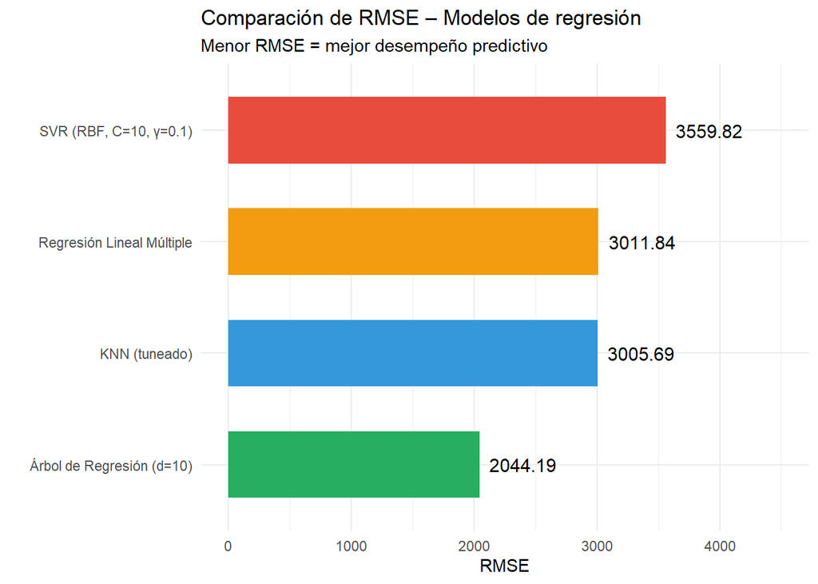

```r
# Gráfico comparativo de RMSE (excluyendo Naive Bayes por inconsistencia metodológica)
comparacion_plot <- comparacion_reg[comparacion_reg$Modelo != "Naive Bayes (laplace=0)*", ]

ggplot(comparacion_plot,
       aes(x = reorder(Modelo, RMSE), y = RMSE, fill = Modelo)) +
  geom_bar(stat = "identity", width = 0.6) +
  geom_text(aes(label = round(RMSE, 2)), hjust = -0.15, size = 4) +
  coord_flip() +
  ylim(0, 4500) +
  scale_fill_manual(values = c(
    "Árbol de Regresión (d=10)"  = "#27ae60",
    "KNN (tuneado)"              = "#3498db",
    "Regresión Lineal Múltiple"  = "#f39c12",
    "SVR (RBF, C=10, γ=0.1)"    = "#e74c3c"
  )) +
  labs(
    title   = "Comparación de RMSE – Modelos de regresión",
    subtitle = "Menor RMSE = mejor desempeño predictivo",
    x = "", y = "RMSE"
  ) +
  theme_minimal() +
  theme(legend.position = "none")
```

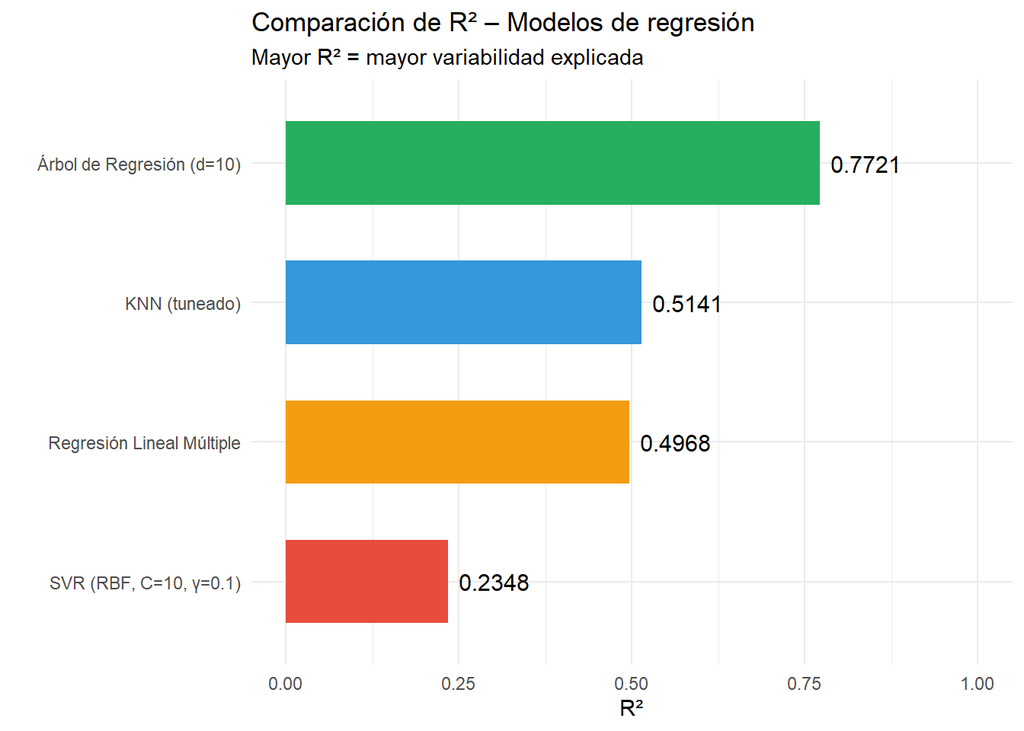

```r
# Gráfico comparativo de R²
ggplot(comparacion_plot,
       aes(x = reorder(Modelo, R2), y = R2, fill = Modelo)) +
  geom_bar(stat = "identity", width = 0.6) +
  geom_text(aes(label = round(R2, 4)), hjust = -0.15, size = 4) +
  coord_flip() +
  ylim(0, 1) +
  scale_fill_manual(values = c(
    "Árbol de Regresión (d=10)"  = "#27ae60",
    "KNN (tuneado)"              = "#3498db",
    "Regresión Lineal Múltiple"  = "#f39c12",
    "SVR (RBF, C=10, γ=0.1)"    = "#e74c3c"
  )) +
  labs(
    title    = "Comparación de R² – Modelos de regresión",
    subtitle = "Mayor R² = mayor variabilidad explicada",
    x = "", y = "R²"
  ) +
  theme_minimal() +
  theme(legend.position = "none")
```

Al comparar los modelos de regresión evaluados sobre el conjunto de prueba, el Árbol de Regresión con profundidad 10 es el mejor modelo con un RMSE de 2,044 y un R² de 0.77, explicando el 77% de la variabilidad del precio. Esto se debe a su capacidad para capturar relaciones no lineales entre variables como accommodates, bedrooms y bathrooms, que un modelo lineal no puede modelar adecuadamente. Le siguen KNN tuneado (RMSE = 3,005, R² = 0.51) y Regresión Lineal Múltiple (RMSE = 3,011, R² = 0.50), prácticamente empatados, explicando alrededor de la mitad de la variabilidad del precio.

El SVR con kernel RBF quedó en la última posición entre los modelos comparables, con el RMSE más alto (3,559) y el R² más bajo (0.23). Aunque el tuneo automático seleccionó C=10 y γ=0.1 como mejores parámetros, el espacio de búsqueda fue limitado (solo 4 combinaciones), lo que restringe su potencial. Adicionalmente, la distribución altamente dispersa del precio con valores extremos dificulta que el SVM encuentre una función de regresión adecuada. Para SmartStay, el Árbol de Regresión sigue siendo la herramienta más confiable para estimar precios numéricos de propiedades.

**Nota de Naive Bayes** aunque tiene el RMSE más bajo (1,761), su R² de −4.99 es un mal indicio. Un R² negativo significa que el modelo es peor que simplemente predecir la media del precio para todos los casos. Esto ocurre porque el modelo fue evaluado sobre test_reg2, que es solo el 30% de una muestra del 30% del dataset original, lo que hace que su RMSE bajo no sea comparable directamente con los demás modelos que usaron particiones distintas